# Homework 5

Stat 452

Author

Alicie

For this assignment, I want you to work on your own in your own file, generating ideas by yourself so that when you work with your partner, you’ll have twice the number of ideas.

## Data Context

1. Read the following two journal articles about the ACTIVE study.
- https://www.ncbi.nlm.nih.gov/pmc/articles/PMC3934012/
- https://www.ncbi.nlm.nih.gov/pmc/articles/PMC4055506/

Add the citations of these papers to the `Library.bib` file in the Github Repo by going to https://www.scholar.google.com and typing the article title. Find the article by double checking authors and titles. Click on Cite and then Bibtex and copy the @Article{key, …} text below into the `Library.bib` file.

ANSWER:The ACTIVE study examined whether cognitive training could help older adults maintain cognitive health and functional independence. Participants were randomly assigned to memory training, reasoning training, speed-of-processing training, or a no-contact control group in a single-blind trial. The study initially enrolled 2,832 adults aged 65 and older who lived in the community and did not have significant cognitive dysfunction (Tennstedt and Unverzagt 2013). The assessments over ten years included cognitive tests, participants’ reports of difficulties with daily activities, and performance-based measures of everyday functioning. At ten years, participants in all three training groups reported less decline in their ability to perform instrumental activities of daily living than those in the control group. Reasoning and speed training, but not memory training, led to lasting improvements in the targeted cognitive abilities over ten years (Rebok et al. 2014).

## Research Question

3. Develop a “linear regression” research question you’d like to explore about aging related to the clinical trial.

Outcome Ideas (choose 1): Reasoning, Memory, Speed of Processing, Functional Outcomes

Predictors: Treatment Group, Years, Baseline Age, Gender, Baseline Values [of any outcome], Interactions, Reasoning, Memory, Speed of Processing, Functional Outcomes

ANSWER:Does memory performance change differently over time for people in the memory training group compared with those in the control group?

4. Load in the ACTIVE study data and come up with two high quality graphs that provide insight about your research question.

ANSWER:

```r
source('cleaning_active.R') # Open Cleaning.R to see the data cleaning steps to create a long format dataset & more info about each variable
head(activeLong)
```

```
  AID                       INTGRP REPLCODE SITE BOOSTER GENDER AgeAtBaseline
1   1              Memory Training        5    1       1      1            76
2   2              Memory Training        2    1       1      2            67
3   3 Speed of Processing Training        6    6       1      2            67
4   4 Speed of Processing Training        4    3       1      2            78
5   5              Memory Training        3    5       1      2            72
6   6                      Control        2    4       0      2            69
  YRSEDUC DEATH_INDICAT DEATH_DUR time ADLT AVLTT  CRT1  CRT2 DAVOID DRIVER
1      12             0        NA    7   NA    NA    NA    NA     NA     NA
2      10             1      3506    7   NA    NA    NA    NA     NA     NA
3      13             0        NA    7    0    28 1.746 3.005      0      1
4      13             1      1706    7   NA    NA    NA    NA     NA     NA
5      16             0        NA    7    0    NA    NA    NA      0      1
6      12             0        NA    7    0    53 1.596 2.490     25      1
  DTOTP EPT HVLTT IMMRAW LSCOR LTCOR MMSE OTDL PTOTP      TIADL TOTDD TOTDS
1    NA  NA    NA     NA    NA    NA   NA   NA    NA         NA    NA    NA
2    NA  NA    NA     NA    NA    NA   NA   NA    NA         NA    NA    NA
3     0  21    17    2.5    10     6   28   27     0 -0.3942510 0.000     2
4    NA  NA    NA     NA    NA    NA   NA   NA    NA         NA    NA    NA
5     0  26    NA     NA    NA    NA   NA   NA     0         NA 4.167     2
6     0  22    29    6.5     9     6   27   20     0 -0.3218141 0.000     4
  UFOV1 UFOV2 UFOV3 UFOV4 WSCOR Years Age Memory Reasoning Speed
1    NA    NA    NA    NA    NA    10  86     NA        NA    NA
2    NA    NA    NA    NA    NA    10  77     NA        NA    NA
3    17    40   150   370     6    10  77   47.5        22   577
4    NA    NA    NA    NA    NA    10  88     NA        NA    NA
5    NA    NA    NA    NA    NA    10  82     NA        NA    NA
6    17   160   237   500    12    10  79   88.5        27   914
```

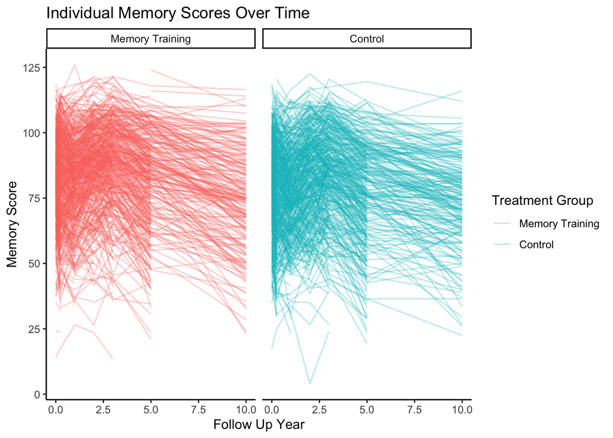

```r
memory_data <- activeLong %>%
  filter(INTGRP %in% c("Memory Training", "Control"))

memory_data %>%
  ggplot(aes(x = Years, y = Memory, color = INTGRP, group = AID)) +
  geom_line(alpha = 0.3) +
  facet_wrap(~ INTGRP) +
  labs(
    title = "Individual Memory Scores Over Time",
    x = "Follow Up Year",
    y = "Memory Score",
    color = "Treatment Group"
  ) +
  theme_classic()
```

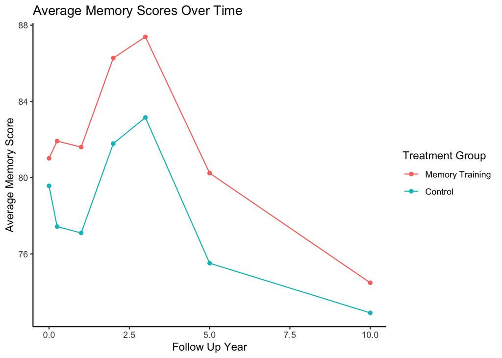

```r
memory_data %>%
  group_by(INTGRP, Years) %>%
  summarize(Memory = mean(Memory, na.rm = TRUE)) %>%
  ggplot(aes(x = Years, y = Memory, color = INTGRP)) +
  geom_point() +
  geom_line() +
  labs(
    title = "Average Memory Scores Over Time",
    x = "Follow Up Year",
    y = "Average Memory Score",
    color = "Treatment Group"
  ) +
  theme_classic()
```

## Models

5. Use those graphs to inform fitting a series of linear models (using `lm`) predicting the outcome of your choice (as it relates to your research question). Make sure to consider interactions (whether the effect is the same within treatment groups). Provide code and output for one model that you feel is informative about your research question.

ANSWER:

```r
memory_data <- memory_data %>%
  mutate(INTGRP = relevel(INTGRP, ref = "Control"))

model1 <- lm(Memory ~ Years + INTGRP, data = memory_data)

model2 <- lm(Memory ~ factor(Years) + INTGRP, data = memory_data)

model3 <- lm(Memory ~ factor(Years) * INTGRP, data = memory_data)

summary(model3)
```

```
Call:
lm(formula = Memory ~ factor(Years) * INTGRP, data = memory_data)

Residuals:
    Min      1Q  Median      3Q     Max
-77.789 -11.046   1.612  12.612  44.394

Coefficients:
                                        Estimate Std. Error t value Pr(>|t|)
(Intercept)                              79.5740     0.6954 114.430  < 2e-16
factor(Years)0.25                        -2.1375     0.9834  -2.173 0.029781
factor(Years)1                           -2.4732     1.0383  -2.382 0.017247
factor(Years)2                            2.2146     1.0580   2.093 0.036377
factor(Years)3                            3.5842     1.0855   3.302 0.000965
factor(Years)5                           -4.0577     1.1406  -3.558 0.000377
factor(Years)10                          -6.6642     1.3967  -4.771 1.87e-06
INTGRPMemory Training                     1.4446     0.9842   1.468 0.142221
factor(Years)0.25:INTGRPMemory Training   3.0406     1.3902   2.187 0.028768
factor(Years)1:INTGRPMemory Training      3.0606     1.4638   2.091 0.036578
factor(Years)2:INTGRPMemory Training      3.0440     1.4869   2.047 0.040681
factor(Years)3:INTGRPMemory Training      2.7850     1.5227   1.829 0.067448
factor(Years)5:INTGRPMemory Training      3.2793     1.6048   2.043 0.041056
factor(Years)10:INTGRPMemory Training     0.1341     1.9550   0.069 0.945303

(Intercept)                             ***
factor(Years)0.25                       *
factor(Years)1                          *
factor(Years)2                          *
factor(Years)3                          ***
factor(Years)5                          ***
factor(Years)10                         ***
INTGRPMemory Training
factor(Years)0.25:INTGRPMemory Training *
factor(Years)1:INTGRPMemory Training    *
factor(Years)2:INTGRPMemory Training    *
factor(Years)3:INTGRPMemory Training    .
factor(Years)5:INTGRPMemory Training    *
factor(Years)10:INTGRPMemory Training
---
Signif. codes:  0 '***' 0.001 '**' 0.01 '*' 0.05 '.' 0.1 ' ' 1

Residual standard error: 17.34 on 6533 degrees of freedom
  (3260 observations deleted due to missingness)
Multiple R-squared:  0.04157,   Adjusted R-squared:  0.03966
F-statistic:  21.8 on 13 and 6533 DF,  p-value: < 2.2e-16
```

6. Write about 500 words of what you learn from fitting those models. Make sure you interpret the coefficients accurately and in context.

ANSWER:The individual memory score graph has many overlapping lines, making it hard to see differences between groups or the overall pattern over time. However, the average memory scores show changes over time that do not follow a straight-line pattern. Both groups reach their highest observed averages around year 3 and have lower scores at years 5 and 10. The memory training group has higher average scores throughout years, although the size of the difference changes. These patterns led me to treat follow-up year as a categorical predictor and include an interaction between year and treatment group. Since the graph shows that the gap between the two groups changes over time, including an interaction allows the model to reflect this pattern rather than assuming the same difference in average memory scores at every follow-up time.

In this model, the control group is the reference group, and year 0 represents baseline. The intercept is 79.57, which means that the estimated average memory score for the control group at baseline is 79.57. The coefficient for the memory training group is 1.44, meaning that its estimated average memory score at baseline is 1.44 points higher than the control group’s. Adding these two values gives an estimated baseline average of approximately 81.02 for the memory training group. This difference does not represent the effect of training because baseline scores were measured before the training intervention.

For the control group, each year coefficient shows how much the estimated average memory score differs from baseline. The coefficient for year 2 is 2.21, meaning that the average score is 2.21 points higher than at baseline. Using the unrounded estimates gives an estimated average of 81.79 at year 2. At year 3, the average is 3.58 points higher than at baseline. By years 5 and 10, however, it is respectively 4.06 and 6.66 points lower than at baseline. This shows that there’s an increase in memory scores at years 2 and 3, but declines below baseline at years 5 and 10 without training.

For the memory training group, the interaction coefficients show how its change from baseline differs from the control group’s change. The interaction coefficient for year 2 is 3.04, meaning that the increase from baseline is 3.04 points greater than in the control group. Adding this to the control group’s increase, using the unrounded estimates, gives an estimated increase of 5.26 points for the memory training group. At year 5, the interaction coefficient is 3.28, meaning that the decline from baseline is 3.28 points smaller than in the control group. However, by year 10, the interaction coefficient is only 0.13, suggesting that the two groups have similar declines from their own baseline averages and that the difference in their changes has become smaller.

The model explains about 4.2% of the variation in memory scores, so a high proportion of the variation is still unexplained. Also, 3,260 observations were removed because of missing values, meaning that the averages at different follow-up times may not represent exactly the same participants. Although some interaction terms have p-values below 0.05, these p-values are calculated under the assumption of independent errors. Since each participant was measured repeatedly, we cannot rely on these p-values to conclude that the changes differ significantly between the two groups. Overall, the estimates suggest that the memory training group had greater early improvements, but by year 10, the two groups had similar changes from their own baseline averages.

## Done!

- Render your homework.
- Make sure the html file looks like you want it.
- Submit your assignment as instructed.

## References

Rebok, George W, Karlene Ball, Lin T Guey, et al. 2014. “Ten-Year Effects of the ACTIVE Cognitive Training Trial on Cognition and Everyday Functioning in Older Adults.” *Journal of the American Geriatrics Society* 62 (1): 16.

Tennstedt, Sharon L, and Frederick W Unverzagt. 2013. “The ACTIVE Study: Study Overview and Major Findings.” In *Journal of Aging and Health*, 8_suppl, vol. 25. Sage Publications, Sage CA: Los Angeles, CA.